### The impact of body size on Aedes [Stegomyia] aegypti wingbeat frequency: implications for mosquito identification

Supplemental material for the paper

#### Barbara de Nadai<sup>1</sup>, André Maletzke<sup>2</sup>, Juliano Corbi<sup>1</sup>, Gustavo Batista<sup>3</sup>, and Michael Reiskind<sup>4</sup>

<sup>1</sup> University of São Paulo <sup>2</sup> Western Parana State University <sup>3</sup> University of New South Wales

<sup>4</sup> North Carolina State University

## Libraries required for data analysis

```r
library(cowplot)
library(ggplot2)
library(lme4)
library(emmeans)
```

### The experiments were conducted with females Aedes aegypti mosquitoes.

## Does mosquitoes reared at two different larval densities vary in size?

The difference between the body sizes (wing length and dry weight) from the high and low larval density rearing conditions was analyzed using an unpaired t-test.

```r
data_1 <- read.csv("data/data_1.csv")

t_wingLength <- t.test(data_1$WingLength ~ data_1$Density)
print(t_wingLength)

t_weight <- t.test(data_1$Weight ~ data_1$Density)
print(t_weight)
```

[output not shown]

## Does mosquitoes’ size impact the wingbeat frequency?

```r
mod_ancova <- aov(Wbf ~ WingLength*Weight + Density, data=dtx)
print(summary(mod_ancova))
```

[output not shown]

## Is there a significant difference between the mean wingbeat frequency of mosquitoes from low and high larval densities?

To assess differences between the mean wingbeat frequency of females from low and high larval densities we performed a t-test.

```r
print(t.test(data_2$Wbf ~ data_2$Density))
```

[output not shown]

## Is there any correlation between the wingbeat frequency and wing length, and dry weight?

To demonstrate the correlation between the variables, we performed a linear regression and scatter plot of the female Aedes aegypti wingbeat frequency versus the wing length and dry weight.

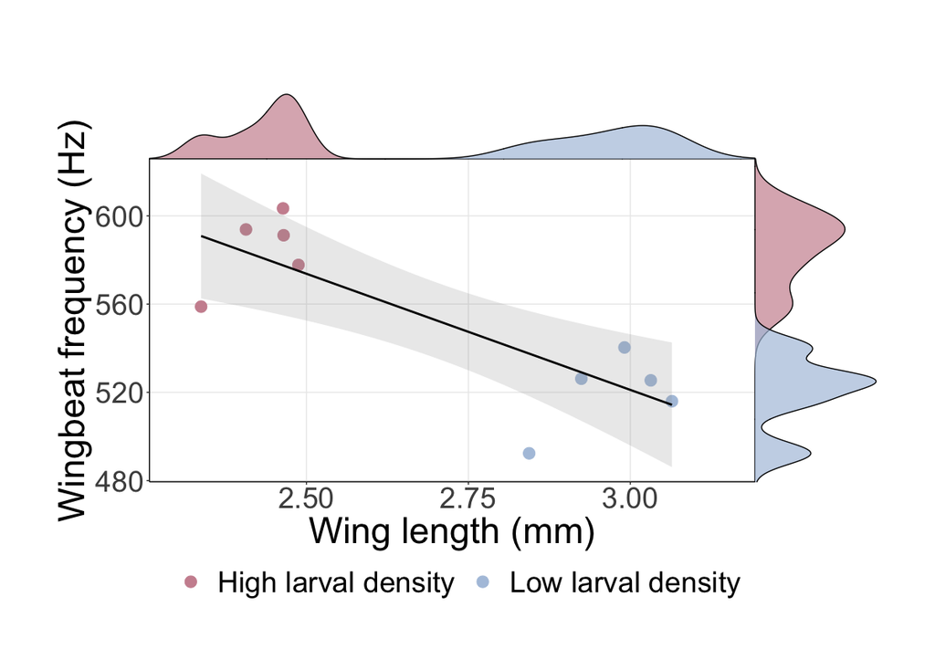

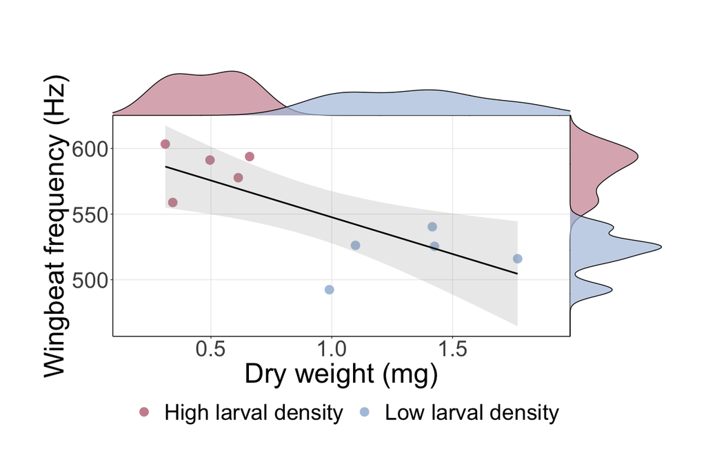

```r
data_2 <- read.csv("data/data_2.csv")

plot_scatter_density <- function(dt, x1, y1, xcolor, xlim, ylim, x_label, s_colors){
  # Main plot
  pmain <- ggplot(dt, aes_string(x = x1, y = y1, color = xcolor))+
    geom_point(aes_string(color=xcolor), size=5)+
    expand_limits(x=xlim, y=ylim)+
    scale_color_manual(values=s_colors, labels = c("High larval density", "Low larval density"))+
    scale_fill_manual(values=s_colors,
                      breaks=c("Low", "High"),
                      labels = c("High larval density", "Low larval density"))+
    geom_smooth(method=lm, color="black", alpha=0.2)+
    labs(x=x_label, y = "Wingbeat frequency (Hz)")+
    theme(legend.text=element_text(size=28))+
    theme(
      plot.background = element_blank()
      ,panel.grid.major = element_line(size = 0.5, linetype = 'solid')
      ,panel.grid.minor = element_blank()
      ,panel.border = element_blank()
      ,text = element_text(size=35),
      strip.background=element_rect(fill="black"),
      legend.position="bottom",
      legend.title = element_blank(),
      legend.background = element_blank(),
      axis.line.x = element_line(size=0.5),
      axis.line.y = element_line(size=0.5),
      plot.margin = margin(3.2,2,2,2, "cm")
    )
  # Marginal densities along x axis
  xdens <- axis_canvas(pmain, axis = "x")+
    geom_density(data = dt, aes_string(x = x1, fill = xcolor),
                 alpha = 0.7, size = 0.5)+
    scale_fill_manual(values=rev(s_colors),
                      breaks=c("Low", "High"),
                      labels = c("Low larval density", "High larval density"))

  # Marginal densities along y axis
  # Need to set coord_flip = TRUE, if you plan to use coord_flip()
  ydens <- axis_canvas(pmain, axis = "y", coord_flip = TRUE)+
    geom_density(data = dt, aes_string(x = y1, fill = xcolor),
                 alpha = 0.7, size = 0.5)+
    scale_fill_manual(values=rev(s_colors),
                      breaks=c("Low", "High"),
                      labels = c("Low larval density", "High larval density"))+
    coord_flip()

  p1n <- insert_xaxis_grob(pmain, xdens, grid::unit(.2, "null"), position = "top")
  p2n<- insert_yaxis_grob(p1n, ydens, grid::unit(.2, "null"), position = "right")

  print(ggdraw(p2n))
}
s_colors_female <- c("pink3", "lightsteelblue")

# Getting the mean weight and wing lenght for each mosquito
dtx <- as.data.frame(aggregate(list(data_2[,c("Temperature","Wbf")]), by=list(data_2$Mosquito_ID,
                                                                              data_2$Density,
                                                                              data_2$Weight,
                                                                              data_2$WingLength), FUN=mean))

names(dtx) <- c("Mosquito","Density", "Weight", "WingLength", "Temperature","Wbf")

plot_scatter_density(dtx, "Weight", "Wbf", "Density",
                    c(0.18, 1.9), c(500, 605), "Dry weight (mg)",
                    s_colors =  s_colors_female)

plot_scatter_density(dtx, "WingLength", "Wbf", "Density",
                    c(2.3, 3.15), c(500, 605), "Wing length (mm)",
                    s_colors =  s_colors_female)

lm_WL <- lm(Wbf ~ WingLength, data=dtx)
print(lm_WL)
print(summary(lm_WL))

print("-------------------------------------------------------------------")

lm_W <- lm(Wbf ~ Weight, data=dtx)
print(lm_W)
print(summary(lm_W))
```

[output not shown]

## Does the temperature impact the wingbeat frequency?

We performed a box plot showing the effect of temperature on wingbeat frequency.

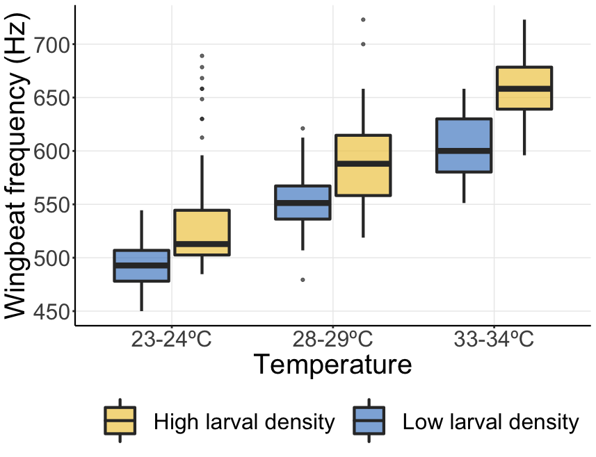

```r
re <- read.csv("data/data_3.csv")

cols <- c("Low larval density" = "#548DCB", "High larval density"="#F0CB52")

re$Density <- factor(re$Density, levels = c("Low larval density", "High larval density"))

p1 <- ggplot(re, aes(x = Range, y = Wbf,fill=Density))+
  geom_boxplot(alpha=0.7, lwd=1.5)+
  xlab("Temperature") +
  ylab("Wingbeat frequency (Hz)") +
  scale_fill_manual(values=cols,
                    breaks=c("Low larval density", "High larval density"),
                    labels = c("Low larval density", "High larval density"))+
  theme_bw()+
  guides(fill=guide_legend(reverse = TRUE))+
  theme(
    plot.background = element_blank()
    ,panel.grid.minor = element_blank()
    ,panel.border = element_blank(),
    text = element_text(size=30),
    legend.position = "bottom",#c(0.8, 0.176),
    legend.title = element_blank(),
    legend.background = element_blank(),
    axis.line.x = element_line(size=.8),
    axis.line.y = element_line(size=.8),
    legend.key.width = unit(1.5,"cm"),
    legend.key.height= unit(2,"cm"),
    axis.ticks = element_line(size = 1)
  ) +
  #draws x and y axis line
  theme(axis.line = element_line(color = 'black'))

print(p1)
```

## What are the effects of temperature and body size on the wingbeat frequency?

The effects of temperature and body size, as well as their interactions were analyzed via a linear mixed model (LMM) with each group of 10 mosquitoes considered a random effect.

```r
re <- read.csv("data/data_4.csv")

re$Tray <- as.factor(re$Tray)
re$Density <- as.factor(re$Density)
re$Range <- as.factor(re$Range)

print("==============================================================")

model <- lmer(Wbf ~ Range + Density + Range:Density + (1|Tray), data=re)

print(summary(model))
print("----------------------------------------------------")
print(anova(model))
print("----------------------------------------------------")
print(emmeans(model, pairwise ~ Range + Density + Range:Density, adjust = "tukey"))
```

[output not shown]